# Assignment 1 of the course Big Data Analytics

## 1. Task

**Read the data with a statistic tool of your choice.**

```r
publications <- read.csv("/Users/arturofigueroa/Desktop/Maestria-DataScience/Lectures/2nd-Semester/Big-Data/assigments/publications.csv")
head(publications)
```

```
##   X.PERSON_ID NUMBER_PUBLICATIONS
## 1    123/1810                   1
## 2    264/8251                   2
## 3    251/2963                   1
## 4     08/6448                  12
## 5    143/5209                   1
## 6       19/48                   7
```

```r
str(publications)
```

```
## 'data.frame':    1547534 obs. of  2 variables:
##  $ X.PERSON_ID        : chr  "123/1810" "264/8251" "251/2963" "08/6448" ...
##  $ NUMBER_PUBLICATIONS: int  1 2 1 12 1 7 1 4 10 1 ...
```

```r
summary(publications)
```

```
##  X.PERSON_ID        NUMBER_PUBLICATIONS
##  Length:1547534     Min.   :   0.00
##  Class :character   1st Qu.:   1.00
##  Mode  :character   Median :   2.00
##                     Mean   :  11.51
##                     3rd Qu.:   6.00
##                     Max.   :2211.00
```

**Determine basic statistical features of the number of publications, such as minimum, maximum, lower quartile, upper quartile, median and mean.**

```r
num_pub <- publications$NUMBER_PUBLICATIONS
id <- publications$X.PERSON_ID

max(num_pub)
```

```
## [1] 2211
```

```r
min(num_pub)
```

```
## [1] 0
```

```r
quantile(num_pub)
```

```
##   0%  25%  50%  75% 100%
##    0    1    2    6 2211
```

```r
mean(num_pub)
```

```
## [1] 11.50719
```

```r
median(num_pub)
```

```
## [1] 2
```

**Draw a box plot of the publication number distribution.**

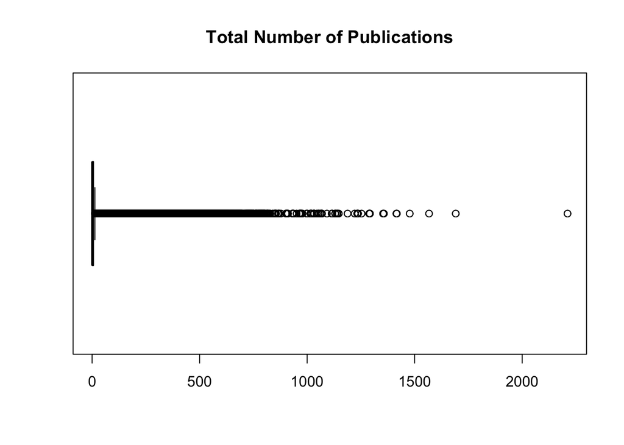

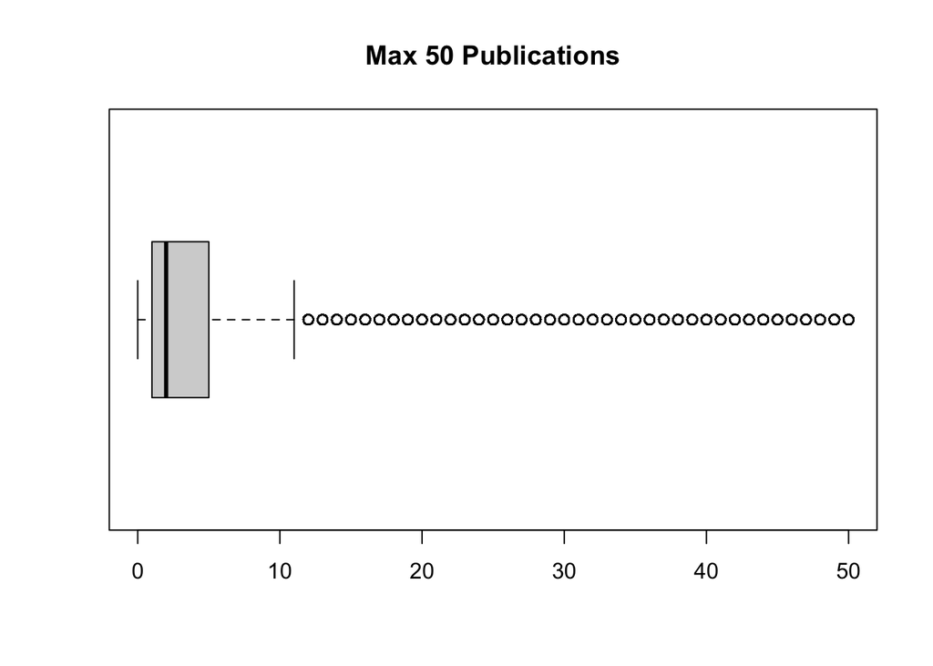

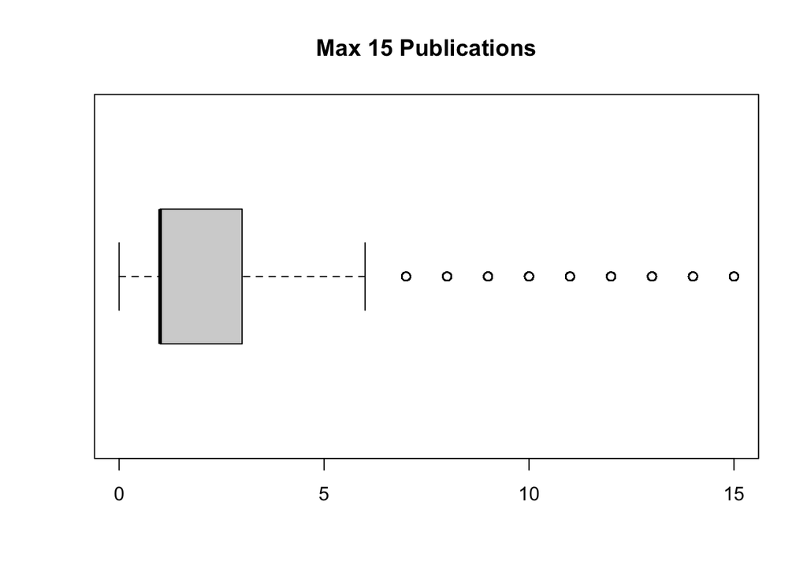

***

- With the box plot we can see the publication number distribution and realize that 50% of the total of publication are in the range of 1 to 6, most of the scientists have been published between this range, the min value is 0 ad the max value is 2211. We can consider the Outliers as a potential issue because a scientists with hundreds or thousands of publications maybe is not accurate and consistency, the data might be correct, but might not be, considering the time that takes to publish one article, also we have to consider duplicate values or event null values.

## 2. Task

**What is the average number of publications per scientist in this example?**

```r
cat("Average number of publications per scientist: ", mean(num_pub) )
```

```
## Average number of publications per scientist:  11.50719
```

**A) Draw a histogram of the publication number distribution.**

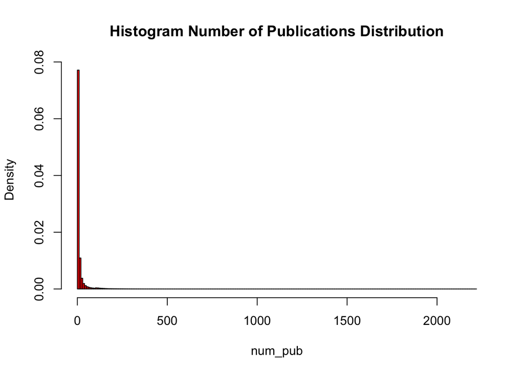

**B) Determine at least two classes of publication numbers that need to be filtered out.**

**1. Class Remove Duplicate IDs:**

```r
pub_unique_id <- unique(publications)

length(publications$X.PERSON_ID)
```

```
## [1] 1547534
```

```r
length(pub_unique_id$X.PERSON_ID)
```

```
## [1] 1526755
```

```r
Total_duplicate <- length(publications$X.PERSON_ID) - length(pub_unique_id$X.PERSON_ID)
cat("Total Duplicate IDs:", Total_duplicate)
```

```
## Total Duplicate IDs: 20779
```

- One class that we determined to be filtered out is duplicate functions. To filter this class we used the unique that returns data frame but with duplicate rows removed. We can see the first length of the original data frame and the second length after removed the duplicate IDs. At the end the difference between the first and second length so we realized how many ID are duplicated.

**2. Class ID with different format:**

```r
library(stringr)

not_null_pub <- pub_unique_id

data_regex <- str_detect(not_null_pub$X.PERSON_ID, "/")

null_id_pub <- which(data_regex == FALSE)

not_null_pub$X.PERSON_ID[null_id_pub]
```

```
## [1] "null" "null" "null" "null" "null"
```

```r
not_null_pub <- not_null_pub[-null_id_pub,]

length(pub_unique_id$X.PERSON_ID)
```

```
## [1] 1526755
```

```r
length(not_null_pub$X.PERSON_ID)
```

```
## [1] 1526750
```

```r
length(null_id_pub)
```

```
## [1] 5
```

```r
pub_unique_id <- not_null_pub
```

- Another class that we considered to filtered out is the IDs that are not in the correct format, or are null, in this case we are not sure if an ID should contain only numbers, letters or both but at least it should have a / slash between numbers or letters. We took this pattern and search through all the ID that does not match and removed from the unique ids data, in this task all the IDs that did not match have the value of “null”.

**3. Class Outliers**

```r
outliers_num <- boxplot.stats(pub_unique_id$NUMBER_PUBLICATIONS)$out

head(sort(outliers_num))
```

```
## [1] 14 14 14 14 14 14
```

```r
tail(sort(outliers_num))
```

```
## [1] 1415 1417 1477 1567 1691 2211
```

```r
sub_pub_unique_id <- subset(pub_unique_id$NUMBER_PUBLICATIONS,
                            pub_unique_id$NUMBER_PUBLICATIONS < min(outliers_num) )
```

- As we saw in the lecture Outliers should be detected, but not necessarily removed. Their inclusion in the analysis is a statistical decision. One potential issues after the first analysis was the outliers because as we said, we can not considered as accurate data a scientist who has published more than hundreds or thousands publications. The R language comes with function boxplot.stats, which, amongst other things, list the outliers. In this method, an observation is an outlier when it is larger than the so-called ``whiskers’’ of the set of observations. The upper whisker is computed by adding 1.5 times the interquartile range to the third quartile and rounding to the nearest lower observation. The lower whisker is computed likewise.

## After filter the data

```r
summary(sub_pub_unique_id)
```

```
##    Min. 1st Qu.  Median    Mean 3rd Qu.    Max.
##   0.000   1.000   1.000   2.589   3.000  13.000
```

```r
max(sub_pub_unique_id)
```

```
## [1] 13
```

```r
min(sub_pub_unique_id)
```

```
## [1] 0
```

```r
quantile(sub_pub_unique_id)
```

```
##   0%  25%  50%  75% 100%
##    0    1    1    3   13
```

```r
mean(sub_pub_unique_id)
```

```
## [1] 2.589005
```

```r
median(sub_pub_unique_id)
```

```
## [1] 1
```

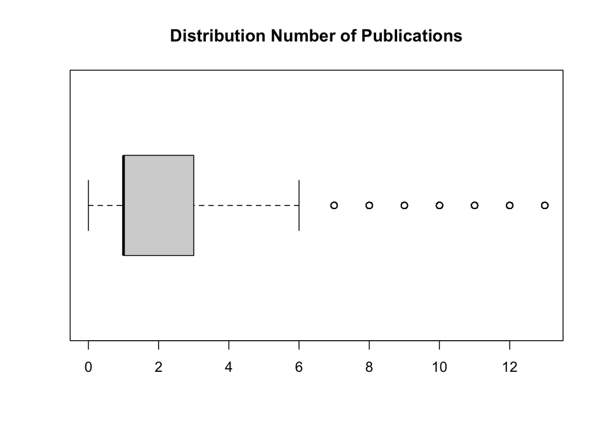

```r
boxplot(sub_pub_unique_id, horizontal = TRUE, main= "Distribution Number of Publications")
```

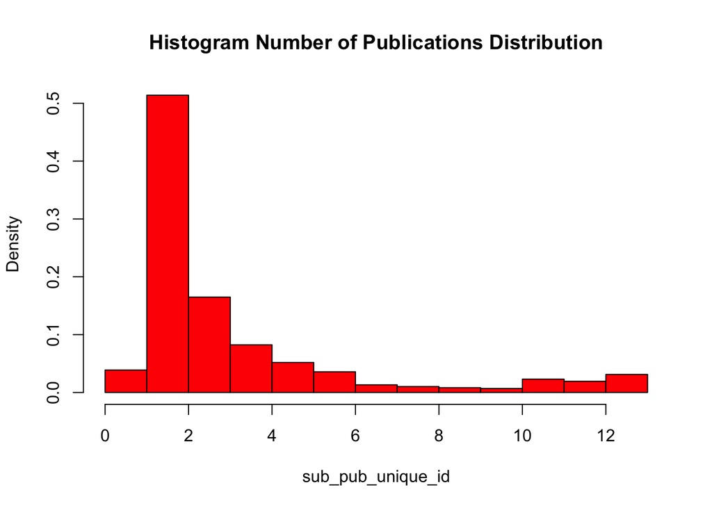

```r
hist(sub_pub_unique_id, main = "Histogram Number of Publications Distribution",
     right = FALSE,
     freq = FALSE, breaks = max(sub_pub_unique_id), col = "red")
```